# Chapter 8 Applied Exercises

# Exercise 9

```r
rm(list = ls())
library(ISLR)
# knowing the data
dim(OJ)  # 1070*18
```

```
## [1] 1070   18
```

```r
sum(is.na(OJ))
```

```
## [1] 0
```

```r
summary(OJ)  # Purchase and Store7 factor variables
```

```
##  Purchase WeekofPurchase     StoreID        PriceCH         PriceMM
##  CH:653   Min.   :227.0   Min.   :1.00   Min.   :1.690   Min.   :1.690
##  MM:417   1st Qu.:240.0   1st Qu.:2.00   1st Qu.:1.790   1st Qu.:1.990
##           Median :257.0   Median :3.00   Median :1.860   Median :2.090
##           Mean   :254.4   Mean   :3.96   Mean   :1.867   Mean   :2.085
##           3rd Qu.:268.0   3rd Qu.:7.00   3rd Qu.:1.990   3rd Qu.:2.180
##           Max.   :278.0   Max.   :7.00   Max.   :2.090   Max.   :2.290
##      DiscCH            DiscMM         SpecialCH        SpecialMM
##  Min.   :0.00000   Min.   :0.0000   Min.   :0.0000   Min.   :0.0000
##  1st Qu.:0.00000   1st Qu.:0.0000   1st Qu.:0.0000   1st Qu.:0.0000
##  Median :0.00000   Median :0.0000   Median :0.0000   Median :0.0000
##  Mean   :0.05186   Mean   :0.1234   Mean   :0.1477   Mean   :0.1617
##  3rd Qu.:0.00000   3rd Qu.:0.2300   3rd Qu.:0.0000   3rd Qu.:0.0000
##  Max.   :0.50000   Max.   :0.8000   Max.   :1.0000   Max.   :1.0000
##     LoyalCH          SalePriceMM     SalePriceCH      PriceDiff
##  Min.   :0.000011   Min.   :1.190   Min.   :1.390   Min.   :-0.6700
##  1st Qu.:0.325257   1st Qu.:1.690   1st Qu.:1.750   1st Qu.: 0.0000
##  Median :0.600000   Median :2.090   Median :1.860   Median : 0.2300
##  Mean   :0.565782   Mean   :1.962   Mean   :1.816   Mean   : 0.1465
##  3rd Qu.:0.850873   3rd Qu.:2.130   3rd Qu.:1.890   3rd Qu.: 0.3200
##  Max.   :0.999947   Max.   :2.290   Max.   :2.090   Max.   : 0.6400
##  Store7      PctDiscMM        PctDiscCH       ListPriceDiff
##  No :714   Min.   :0.0000   Min.   :0.00000   Min.   :0.000
##  Yes:356   1st Qu.:0.0000   1st Qu.:0.00000   1st Qu.:0.140
##            Median :0.0000   Median :0.00000   Median :0.240
##            Mean   :0.0593   Mean   :0.02731   Mean   :0.218
##            3rd Qu.:0.1127   3rd Qu.:0.00000   3rd Qu.:0.300
##            Max.   :0.4020   Max.   :0.25269   Max.   :0.440
##      STORE
##  Min.   :0.000
##  1st Qu.:0.000
##  Median :2.000
##  Mean   :1.631
##  3rd Qu.:3.000
##  Max.   :4.000
```

```r
# knowing the response
contrasts(OJ$Purchase)  # MM is 1 and CH is 0; MM
```

```
##    MM
## CH  0
## MM  1
```

## Part 9.a)

```r
train = sample(1:nrow(OJ), size = 800)
test = -train
test_purchase = OJ$Purchase[test]
```

## Part 9.b)

```r
library(tree)
tree_oj <- tree(Purchase ~ ., data = OJ, subset = train)
summary(tree_oj)
```

```
##
## Classification tree:
## tree(formula = Purchase ~ ., data = OJ, subset = train)
## Variables actually used in tree construction:
## [1] "LoyalCH"        "SalePriceMM"    "SpecialCH"      "WeekofPurchase"
## [5] "ListPriceDiff"  "PctDiscMM"
## Number of terminal nodes:  9
## Residual mean deviance:  0.7141 = 564.8 / 791
## Misclassification error rate: 0.1512 = 121 / 800
```

Deviance is a measure of fit which is equivalent to RSS for cases such as least squares. The smaller the deviance, the better the fit (to the training data). The training error rate is 0.15125 and the tree has 9 terminal nodes.

## Part 9.c)

Here is a detailed text summary of the table:

```r
tree_oj
```

```
## node), split, n, deviance, yval, (yprob)
##       * denotes terminal node
##
##  1) root 800 1072.00 CH ( 0.60750 0.39250 )
##    2) LoyalCH < 0.48285 305  318.60 MM ( 0.21639 0.78361 )
##      4) LoyalCH < 0.136698 103   45.76 MM ( 0.05825 0.94175 ) *
##      5) LoyalCH > 0.136698 202  245.80 MM ( 0.29703 0.70297 )
##       10) SalePriceMM < 2.04 115  112.30 MM ( 0.19130 0.80870 )
##         20) SpecialCH < 0.5 102   81.59 MM ( 0.13725 0.86275 ) *
##         21) SpecialCH > 0.5 13   17.32 CH ( 0.61538 0.38462 ) *
##       11) SalePriceMM > 2.04 87  119.20 MM ( 0.43678 0.56322 )
##         22) WeekofPurchase < 246.5 21   17.22 MM ( 0.14286 0.85714 ) *
##         23) WeekofPurchase > 246.5 66   91.25 CH ( 0.53030 0.46970 ) *
##    3) LoyalCH > 0.48285 495  421.10 CH ( 0.84848 0.15152 )
##      6) LoyalCH < 0.764572 236  277.80 CH ( 0.72458 0.27542 )
##       12) ListPriceDiff < 0.235 91  126.10 MM ( 0.49451 0.50549 )
##         24) PctDiscMM < 0.196197 72   97.80 CH ( 0.58333 0.41667 ) *
##         25) PctDiscMM > 0.196197 19   16.57 MM ( 0.15789 0.84211 ) *
##       13) ListPriceDiff > 0.235 145  112.60 CH ( 0.86897 0.13103 ) *
##      7) LoyalCH > 0.764572 259   84.69 CH ( 0.96139 0.03861 ) *
```

## Part 9.d)

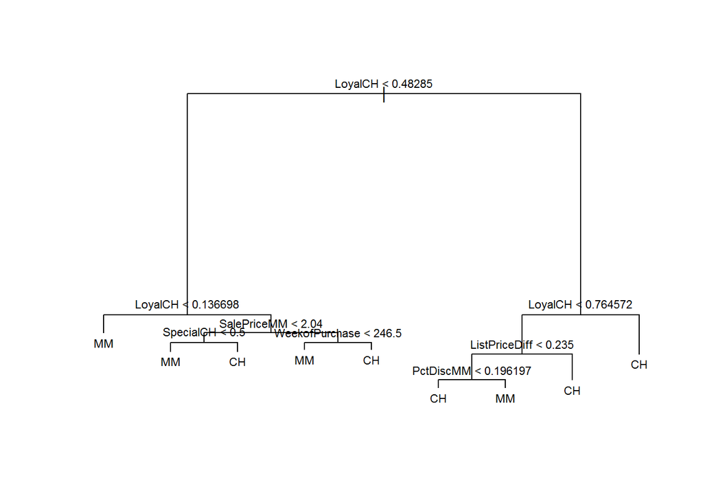

```r
plot(tree_oj)
text(tree_oj, pretty = FALSE, cex = 0.7)
```

## Part 9.e)

```r
preds_oj = predict(tree_oj, newdata = OJ[test, ], type = "class")
table_oj <- table(test_purchase, preds_oj)
table_oj
```

```
##              preds_oj
## test_purchase  CH  MM
##            CH 155  12
##            MM  46  57
```

```r
1 - sum(diag(table_oj))/sum(table_oj)
```

```
## [1] 0.2148148
```

```r
mean(test_purchase != preds_oj)
```

```
## [1] 0.2148148
```

## Part 9.f)

```r
set.seed(1)
(cv_oj = cv.tree(tree_oj, FUN = prune.misclass))
```

```
## $size
## [1] 9 5 2 1
##
## $dev
## [1] 152 150 149 314
##
## $k
## [1]       -Inf   1.750000   4.333333 173.000000
##
## $method
## [1] "misclass"
##
## attr(,"class")
## [1] "prune"         "tree.sequence"
```

## Part 9.g)

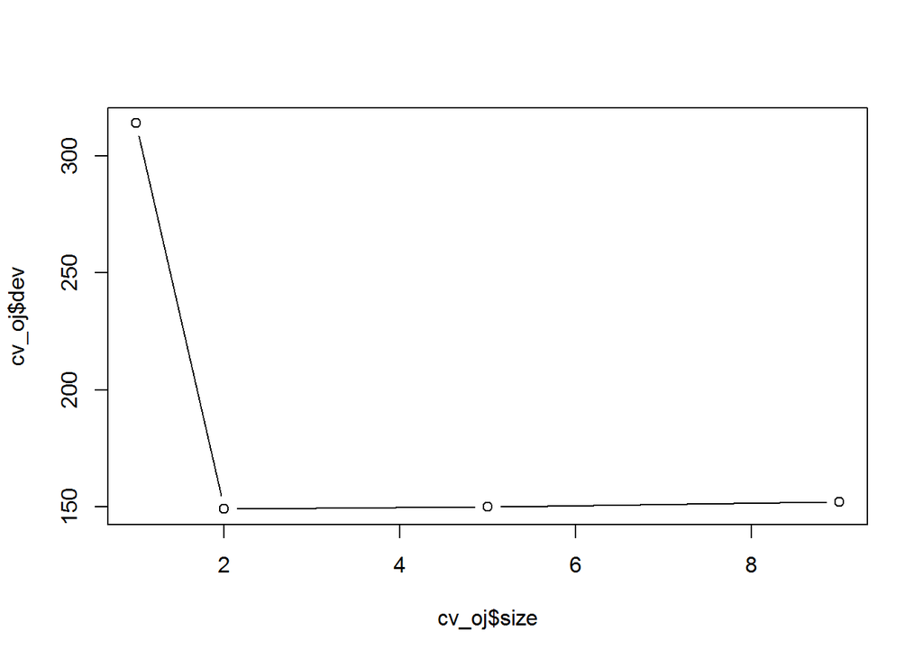

```r
plot(cv_oj$size, cv_oj$dev, type = "b")
```

## Part 9.i)

All the trees we found above by using cost-complexity pruning (done by `cv.tree`) are a subset of sub-trees that can be found using weakest link pruning (done by `prune.tree`). Hence, any tree with a given size $|T|$ is a tree found by weakest link pruning (successively ommiting branches) if and only if it is found by cost-complexity pruning (solving the optimization problem).

As a result, given any tree, all we need to know about the the optimal sub-tree is the size of it. Without knowing anything about the shape of the optimal sub-tree (beyond its size), we can easily find it through weakest link pruning.

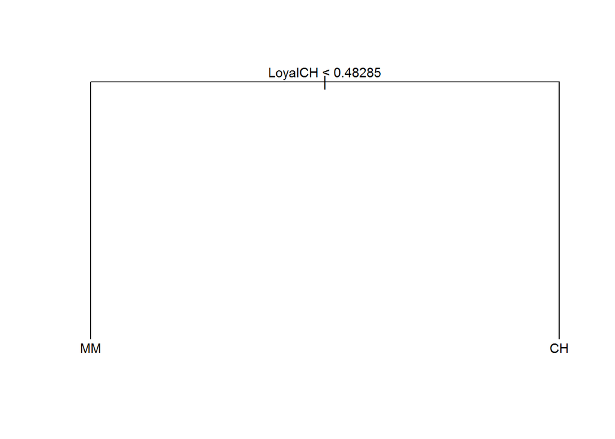

```r
prune_oj = prune.tree(tree_oj, best = 2)
plot(prune_oj)
text(prune_oj, pretty = FALSE, cex = 0.9)
```

## Part 9.j)

```r
# training error rate for full tree
preds_full <- predict(tree_oj, newdata = OJ[train, ], type = "class")
mean(OJ$Purchase[train] != preds_full)
```

```
## [1] 0.15125
```

```r
# training error rate for optimal tree
preds_prune <- predict(prune_oj, newdata = OJ[train, ], type = "class")
mean(OJ$Purchase[train] != preds_prune)
```

```
## [1] 0.17625
```

## Part 9.k)

See part 9.j.